# Project 1: Exploring visdat using fivethirtyeight’s bad_drivers dataset

Mar Heron

```r
# Load R Packages needed
library(visdat)
library(fivethirtyeight)
library(kableExtra)
```

## Description of bad_drivers dataset

The bad_drivers dataset is a part of the fivethirtyeight package in R. It has information about fatal collisions and car insurance for each of the 50 states and the district of Columbia. It has 8 variables and 51 rows. The variables include the following:

- **state**: State
- **num_drivers**: Number of drivers involved in fatal collisions per billion miles
- **perc_speeding**: Percentage of drivers involved in fatal collisions who were speeding
- **perc_alcohol**: Percentage of drivers involved in fatal collisions who were alcohol-impaired
- **perc_not_distracted**: Percentage of drivers involved in fatal collisions who were not distracted
- **perc_no_previous**: Percentage of drivers involved in fatal collisions who hadn’t been involved in any previous accidents
- **insurance_premiums**: Average combined car insurance premiums in U.S. dollars
- **losses**: Losses sustained by insurance companies for collisions per insured driver in U.S. dollars

### Link to bad_drivers dataset:

[bad_drivers dataset](https://fivethirtyeight.com/features/which-state-has-the-worst-drivers/)

## Description of visdat package

The package visdat focuses on visualizing data. Visualizing data makes it easier to identify any issues with the data as well as to figure out the general shape and spread of the data. The three visdat functions that will be explored in this project are as follows:

1. vis_miss()
2. head()
3. vis_dat()

### Function 1

**Code and output:**

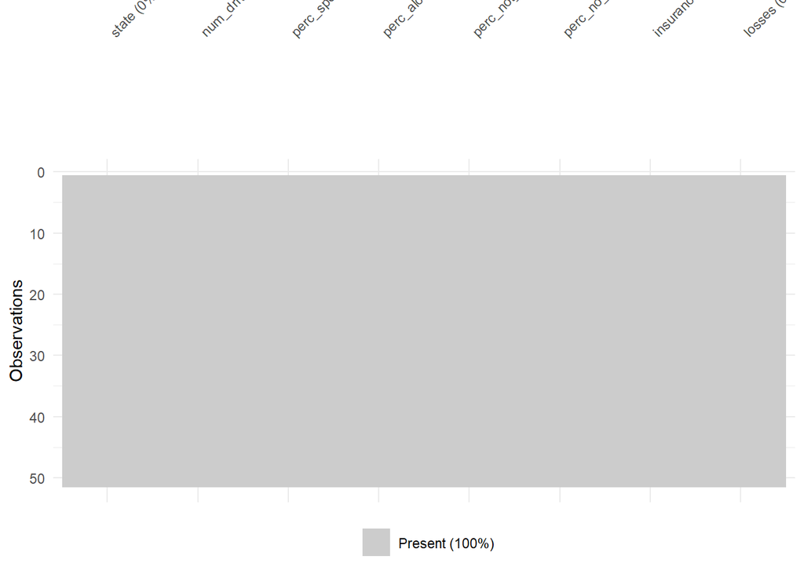

```r
vis_miss(bad_drivers)
```

**Interpretation:** The plot above is the output from the vis_miss function. It shows us how much of our data is missing and which variables the missing values are a part of. Luckily, this plot shows that all of our data is present, meaning there are no cells with missing values.

### Function 2

**Code and output:**

```r
head_bad_drivers <- head(bad_drivers)
kable(head_bad_drivers)
```

| state | num_drivers | perc_speeding | perc_alcohol | perc_not_distracted | perc_no_previous | insurance_premiums | losses |
| --- | --- | --- | --- | --- | --- | --- | --- |
| Alabama | 18.8 | 39 | 30 | 96 | 80 | 784.55 | 145.08 |
| Alaska | 18.1 | 41 | 25 | 90 | 94 | 1053.48 | 133.93 |
| Arizona | 18.6 | 35 | 28 | 84 | 96 | 899.47 | 110.35 |
| Arkansas | 22.4 | 18 | 26 | 94 | 95 | 827.34 | 142.39 |
| California | 12.0 | 35 | 28 | 91 | 89 | 878.41 | 165.63 |
| Colorado | 13.6 | 37 | 28 | 79 | 95 | 835.50 | 139.91 |

**Interpretation:** The output above shows the first 6 rows of the bad_drivers dataset retrieved using the head function. The kable function from the kableExtra package allows all 8 columns to be printed. In this case, the first 6 rows of the data represent the first 6 states in alphabetic order and the corresponding data for those states. This serves as a kind of preview of the data.

### Function 3

**Code and output:**

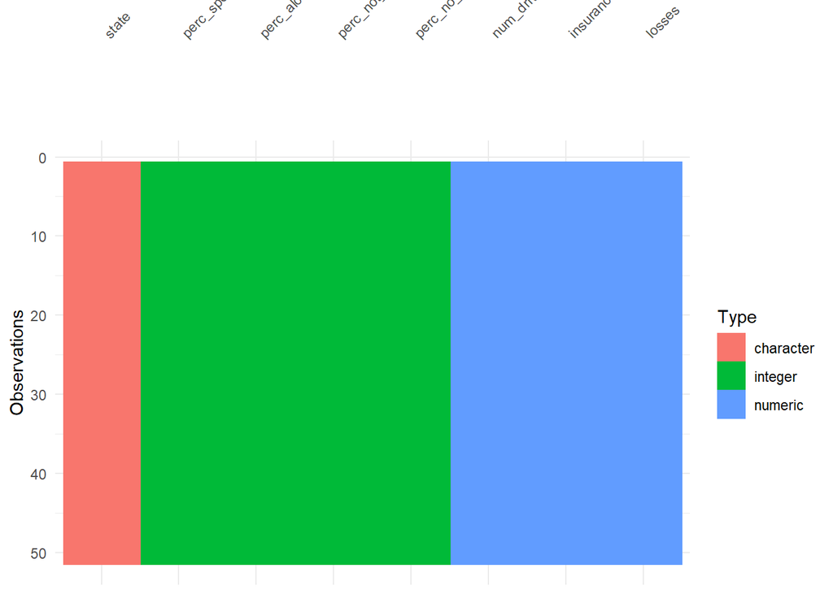

```r
vis_dat(bad_drivers)
```

## Reflection

I think all of these functions could be useful in visualizing data. The vis_miss function allows you to clearly see how much of the data is missing and where the missing values are, which is very useful. The head function allows you to see a small section of the data, letting you see what some of it looks like and allowing you to start looking for patterns. The vis_dat function lets you see the makeup of the variables’ classes, which is helpful for understanding how many variables of each class there are.

With the dataset I chose (bad_drivers), there was a limited number of functions in the visdat package that made sense to use. This made it a little bit difficult to figure out which functions I should use, but I was still able to find multiple functions in the end. One question that popped up as I was exploring the different visdat functions was is there a way to use the vis_expect function using a subset of variables within a dataset? For example, could I make a plot using the vis_expect function that shows the percentages of the values for variables perc_alcohol and perc_speeding that are greater than or equal to 15?